# **2009 Renewable Energy Production Data Analysis**

Alvaro Medel, Fernando Ruiz, Jacob Temple

May 1, 2017

# **Introduction**

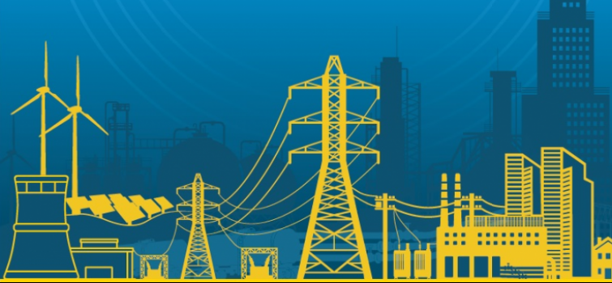

In this R notebook we visualize data from the department of energy that tracks energy production by state in 2009, from renewable energy to oil and gas. We thought this data was intresting because by joining to other data sets (by state) such as the census data we can take an in-depth look at a given state or an overall view of the energy production in the country or trends in certain regions. In the following sections we will show the steps taken to go from raw data from data.world to Tableau and Shiney visualizations.

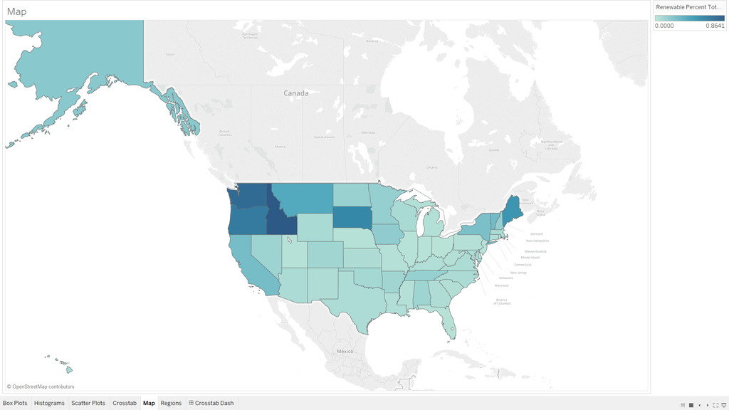

# **Data**

Our main data set: energyByStateClean.csv features state by state information of energy related statistics such as alternative energy production (solar, wind, hydropower), fossil fuel and natural gass energy production, and nuclear energy production in MWH (MegaWatt-Hour) which is a unit of energy with 1MWH being roughly enough energy to power 300 homes for an hour. In our previous project we attempted to use information from the census data to explore the effects of demographics and employment on energy production but found it difficult to establish conclusive relationships which is why in the project we chose to focus on the diffrent facets of the energy production buisness. All of our data was taken directly from data.world, queried and then uploaded to our private data set to be cleaned, further queried and joined to other data sets.

# **R Configuration**

# **ETL**

The following is our ETL which we used to extract and clean our raw data.

```r
#ETL
#1. Load packages
require(jsonlite)
require(readr)
require(plyr)
require(RCurl)

#2. Set up credentials for rest server
redacted = "eyJhbGciOiJIUzUxMiJ9.eyJzdWIiOiJwcm9kLXVzZXItY2xpZW50OmZlcm5hbmRvcnVpeiIsImlzcyI6….39MCSG-bnjjoaMUsOVErEGUxkk4ONQTDPXp9fn6rnnB6VG0guuOX0Km8StzlLCx1lFxbPERrd18iSpfrFJKROg"
username = 'fernandoruiz'

#3.Access rest server
df <- data.frame(fromJSON(getURL(URLencode(gsub("\n", " ",'oraclerest.cs.utexas.edu:5024/rest/native/?query="select `Column A`,`Column C`, `Column E`,`Column G`,`Column I`,`Column K`,`Column M`,`Column O`,`Column Q`, `Column S`,`Column U`,`Column W`,`Column Y`,`Column AA`,`Column AC`,`Column AE`,`Column AG`,`Column AI`, `Column AK` from energyByState"')),httpheader=c(DB='jdbc:data:world:sql:pavilionall:s-17-dv-project-6', USER= username, PASS=redacted, MODE='native_mode', MODEL='model', returnDimensions = 'False', returnFor = 'JSON'), verbose = TRUE) ))
print(summary(df))
print(head(df))


#4.Remove special cheracters
for(n in names(df)) {
  df[n] <- data.frame(lapply(df[n], gsub, pattern="[^ -~]",replacement= ""))
  print(df[n])
}


#5. Since data is taken from data.world we need to fix the column name bug by renaming the columns
colnames(df) <- c("State", "Abbreviation", "Region","Biomass","Geothermal","Solar","Wind","Hydro","HPS","Coal","Petroleum", "Gas","Nuclear" ,"Other", "Non-hydro RE Generation (MWh)", "Total RE Generation (MWh)","Total Generation (MWh)","Non-Hydro Renewable Percent Total Generation", "Renewable Percent Total Generation")

#6. Remove first blank column
df <- df[-1,]

#6. Now we write out our file and add it to our data.world data set:
# https://data.world/jacobbtemple/finalprojectdata

write.csv(file="energyByStateClean.csv", x = df, row.names=FALSE, na = "")


# Load Auxillary Tables
elec <- readr::read_csv('election.csv')
count <- readr::read_csv('county.csv')
eng <- readr::read_csv("energy.csv")
rat <- readr::read_csv("RenewableRatios.csv")


# remove special characters and spaces and set to same case for joining rows.
count[2] <- data.frame(lapply(count[2],tolower))
count[2] <- data.frame(lapply(count[2],gsub,pattern="[^ -~]",replacement = ""))
count[2] <- data.frame(lapply(count[2],gsub,pattern = " ",replacement =""))
elec[2] <- data.frame(lapply(elec[2], gsub, pattern="[^ -~]",replacement= ""))
elec[2] <- data.frame(lapply(elec[2], gsub, pattern =" County" , replacement = ""))
elec[2] <- data.frame(lapply(elec[2], gsub, pattern =" ", replacement ="" ))
elec[2] <- data.frame(lapply(elec[2], tolower))
eng[2] <- data.frame(lapply(eng[2], gsub, pattern = " [^ -~]", replacement = ""))
eng[2] <- data.frame(lapply(eng[2],toupper))
eng[2] <- data.frame(lapply(eng[2],gsub, pattern = " ", replacement = ""))
eng[1] <- data.frame(lapply(eng[1], gsub, pattern = " [^ -~]", replacement = ""))
eng[1] <- data.frame(lapply(eng[1],toupper))
eng[1] <- data.frame(lapply(eng[1],gsub, pattern = " ", replacement = ""))
rat[1] <- data.frame(lapply(rat[1], gsub, pattern = " [^ -~]", replacement = ""))
rat[1] <- data.frame(lapply(rat[1],toupper))
rat[1] <- data.frame(lapply(rat[1],gsub, pattern = " ", replacement = ""))

# Create Cleaned Tables
write.csv(count,"CleanedCounty.csv")
write.csv(elec,"CleanedElection.csv")
write.csv(rat,"CleanedRatios.csv")
write.csv(eng,"CleanedEnergy.csv")

# Create unified data frame
tab <- dplyr::left_join(x = elec, y = count, by = c("County Name" = "county","State Code" = "state" ))
tab <- dplyr::left_join(x =tab, y = eng, by = c("State Code" = "Abbreviation" ))

# Write Unified DataFrame
write.csv(tab,"ElectionWind.csv")
```

# **Vizualization #1**

## Effects of Summer Peak Power and Type of Utility Plant

For this visualization I used additional data sets from the department of energy (and for the same year) which covered information about electrical utility plants, including their revenue (in thousands of dollars), customers, energy production (MWH) and other information such as their summer peak power demand (MW). Here we explore a scatterplot of three different types of utility ownership and their effects on solar power production in the state and their summer peak power demand. We see that where summer peak power demand is high we get more Investor owned utilities without much of an increase in solar power meaning that we should prefer municipal owned utilities to increase our reliance on solar power in hot and sunny places.

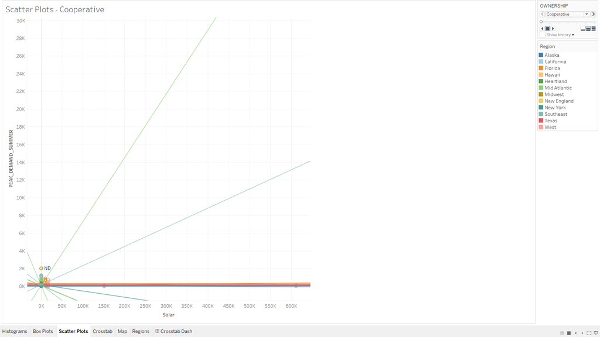

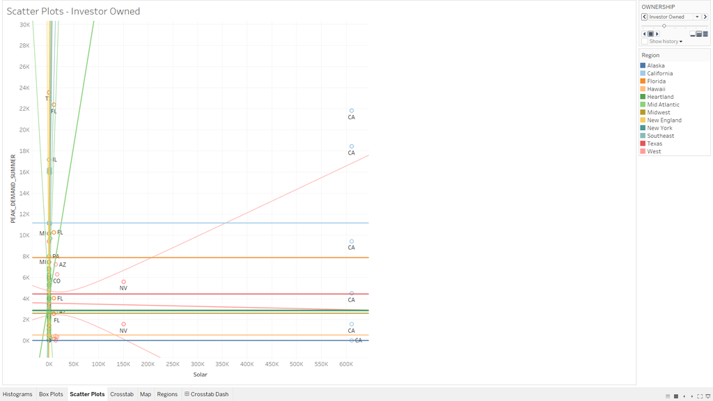

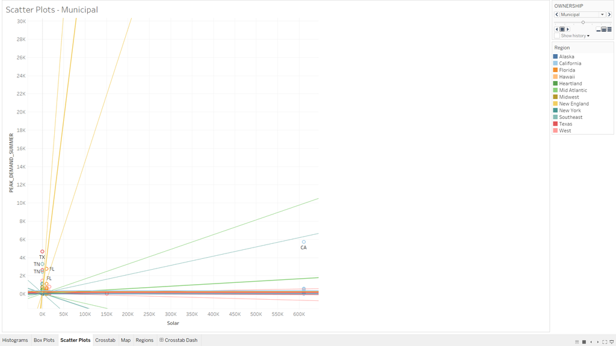

Steps:  
1. Uncheck Aggregate Measures  
2. Drag Peak_Demand_Summer to rows  
3. Filter out Peak_Demand_Summer null values  
4. Drag Solar to columns  
5. Drag Region to color  
6. Drag State to label  
7. Click on the Analytics tab and double click on trend line (linear)  
8. Lastly drag ownership to Pages.

# **Visualizaiton #2**

## Tempest Tantrum: The Limited Political Influence of Windturbine Construction in Rural America:

Despite the central role of fossil fuels in the recent 2016 election, when joining the main dataset with a dataset describing the number of wind turbines constructed in each US county between 2008 and 2014, one finds that the majority of counties with a wind turbine increase in the Obama era actually lost Democratic voters at a higher rate than the national average.

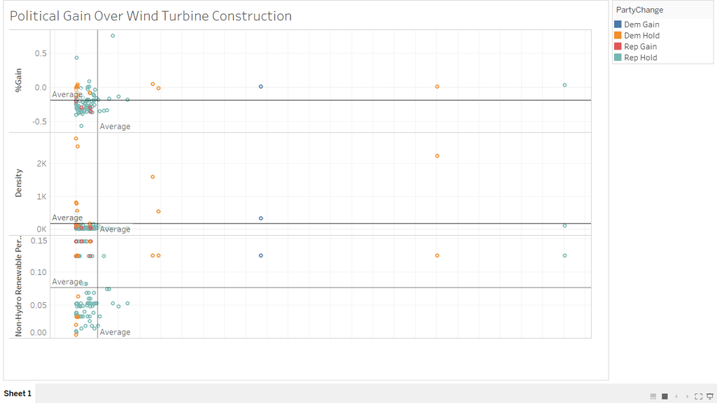

Shiny

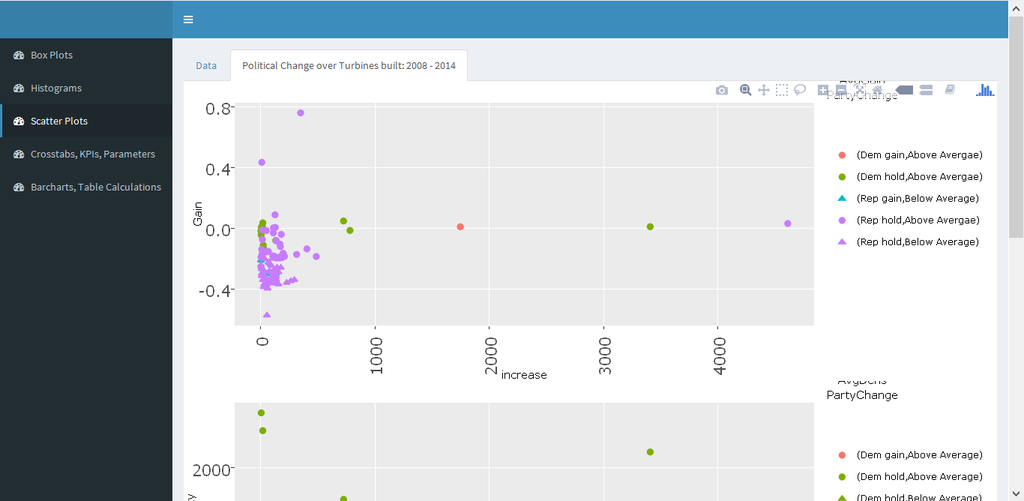

# **Visualizaiton #3**

## FERNANDO MAIN:

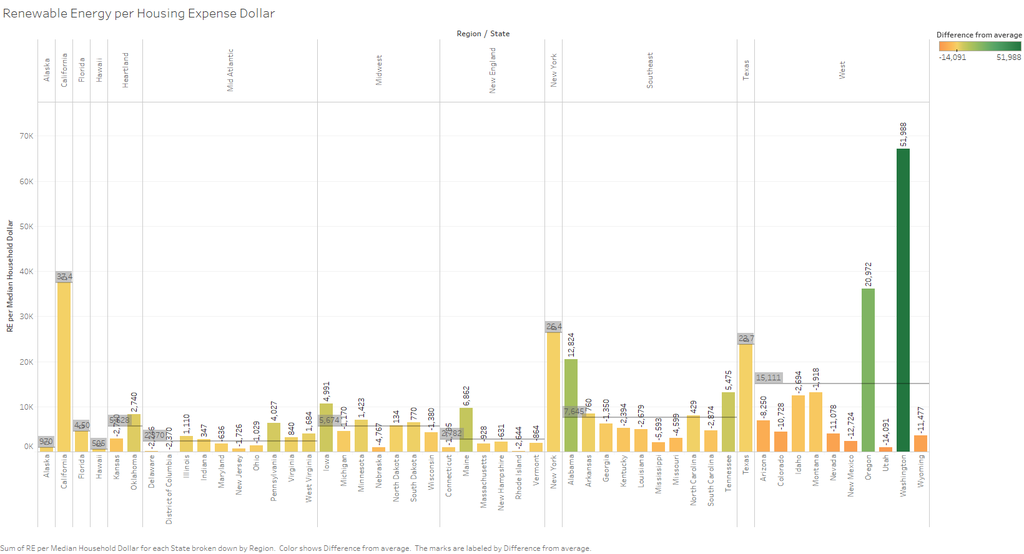

# **Visualizaiton #4**

## ALVARO viz 2: Exploring the data

[figure not shown]

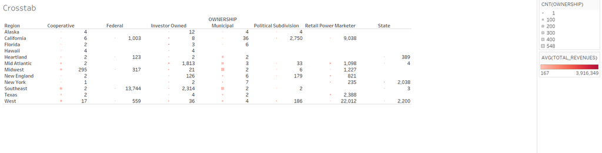

Crosstab  
1. Start with two dimensions: Ownership and Region  
2. Create calculated field PricePerCustomer = Total_Revenues/Total_Customers  
3. Drag PricePerCustomer onto Label and set it to average  
4. Drag Owners to size and set it as a count (to count the number of utilities)  
5. Drag Total_Revenues and set it to color, change color to red

# **Visualizaiton #5**

## ALVARO viz 3: Boxplot Exploration

Here we continue to explore the data by creating a box plot that looks at each region and the percent of renewable energy of each state. I thought it would be interesting to explore the relationship between percent of renewable energy and the peak summer power consumption so I sized each dot by their relative summer peak value (I could have done the same with winter). We see that there are states with very high renewable energy percentage and small peak summer power values which is probably due to the high percentage of wind and other renewables as oppose to solar energy. Also we can see that the regions are somewhat grouped by their similar climate since they share very similar peak summer power values.

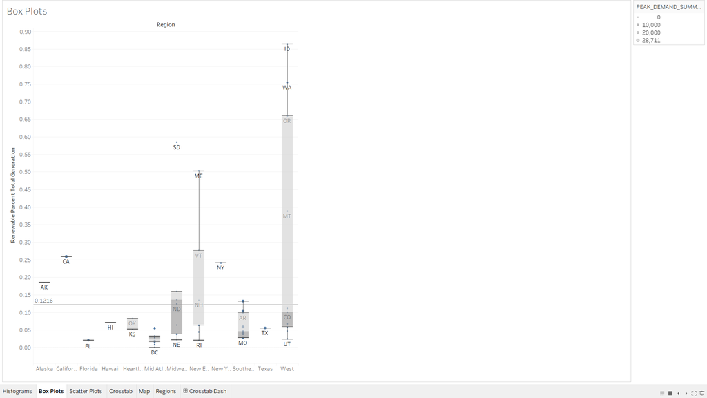

# **Visualizaiton #6**

## Election Results by Relative Strength of Renewable Energy Types:

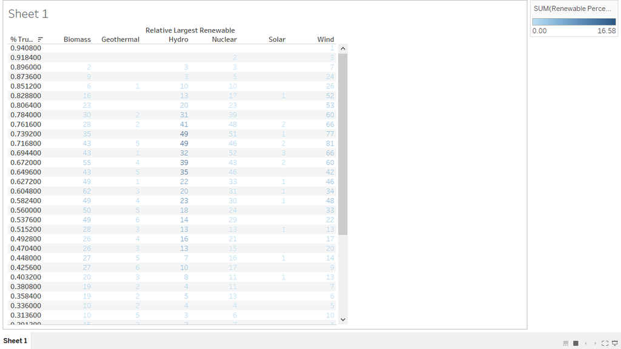

# **Visualizaiton #8**

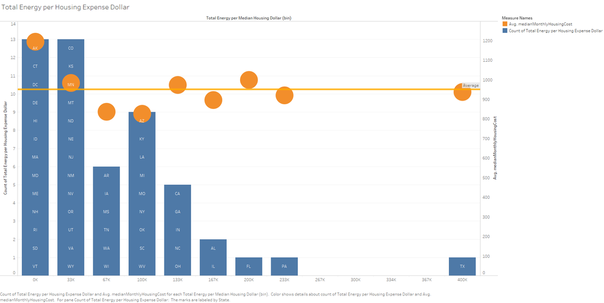

[figure not shown]